# Mendelian Randomization Analysis: Previous Cigarettes per day and Alzheimer's Disease

By Dr. Shea Andrews, generated on 2018-09-06

```
## [1] FALSE
```

## Data sources

*Previous Cigarettes per day*: Summary statisitcs for Smoking Status were genereated from the UK Biobank with participatns asked how many cigarettes they smoked per day if they were former smokers. Results were reported in [NealeLab](https://github.com/Nealelab/UK_Biobank_GWAS), a large database of associations between hundreds of traits and millions of variants using the UK Biobank cohort.

*Late Onset Alzheimer’s disease* [Lambert et al 2013](https://doi.org/10.1038/ng.2802): The International Genomics of Alzheimer’s Project (IGAP) is a meta-analysis of 4 previously published GWAS datasets: the European Alzheimer’s Disease Imitative (EADI), the Alzheimer Disease Genetics Consortium (ADGC), Cohorts for Heart and Aging Research in Genomic Epidemiology (CHARGE), and Genetic and Environmental Risk in AD (GERAD) and includes a sample of 17,008 LOAD cases and 37,154 cognitively normal elder controls. Participants in IGAP were of European ancestry, the average age was 71 and 58.4% of participants were women.

*Alzheimer’s Age of Onset Surivial* [Huang et al 2017](https://doi.org/10.1038/nn.4587): A GWAS of age of onset in LOAD was conducted in 14,406 AD case samples and 25,849 control samples from the IGAP using Cox proportional hazard regressions. Participants were of European ancestry, in cases the the average AAO was 74.8 and 61.7% were women, in controls the average AAE was 79.0 and 59.6% were women.

*CSF Ab42, tau & ptau* [Deming et al 2017](https://doi.org/10.1007/s00401-017-1685-y): A GWAS of CSF AB42, ptau and tau levels (pg/mL) was conducted in 3,146 participants. Participants were of Eurpean ancestry.

*Hippocampal Volume* [Hibar et al 2017](https://doi.org/10.1038/ncomms13624): A GWAS of hippocampal volume perfomed in 26,814 (ENIGMA and CHARGE consortiums) individules of European Ancestry discovered 9 independent loci.

## Instrumental Variables

**LD Clumping:** For standard two sample MR it is important to ensure that the instruments for the exposure are independent. LD clumping can be performed using the data_clump function from the TwoSampleMR package, which uses EUR samples from the 1000 genomes project to estimate LD between SNPs and amonst SNPs that have and LD above a given threshold, only the SNP with the lowest p-value will be retained.

**Proxy SNPs:** SNPs associated with Previous Cigarettes per day were extracted from the GWAS of LOAD, AAOS, AB42, ptau and tau. Where SNPs were not available in the outcome GWAS, the EUR thousand genomes was queried to identified potential proxy SNPs that are in linkage disequilibrium (r2 > 0.8) of the missing SNP.

### Previous Cigarettes per day

Previous Cigarettes per day: 901 SNPs (Table 1) were assoicated with were associated with Previous Cigarettes per day at p < 5e-8. After LD clumping, 878 of 901 SNPs were removed.

**Table 1:** Independent SNPS associated with Previous Cigarettes per day

| SNP | CHR | POS | Effect_allele | Non_Effect_allele | EAF | Beta | SE | P | r2 | N |
| --- | --- | --- | --- | --- | --- | --- | --- | --- | --- | --- |
| rs9379832 | 6 | 26186200 | G | A | 0.2511210 | -0.0265007 | 0.00484262 | 4.45293e-08 | 0.0002641432 | 84456 |
| rs1530848 | 8 | 42552908 | T | G | 0.7726450 | 0.0290411 | 0.00499318 | 6.04329e-09 | 0.0002963061 | 84456 |
| rs113864525 | 9 | 136473053 | A | C | 0.1164810 | 0.0376270 | 0.00650233 | 7.20398e-09 | 0.0002914071 | 84456 |
| rs2002403 | 15 | 78681002 | A | G | 0.0185153 | -0.0955194 | 0.01613280 | 3.21537e-09 | 0.0003316099 | 84456 |
| rs2869030 | 15 | 78711803 | T | G | 0.7666360 | 0.0422553 | 0.00493832 | 1.18145e-17 | 0.0006388743 | 84456 |
| rs6495304 | 15 | 78800416 | A | G | 0.9753126 | 0.0734687 | 0.01335550 | 3.78716e-08 | 0.0002599285 | 84456 |
| rs147760547 | 15 | 78816130 | G | A | 0.0248785 | 0.0751894 | 0.01339060 | 1.97090e-08 | 0.0002743002 | 84456 |
| rs1052035 | 15 | 78841353 | C | T | 0.0475632 | 0.0650843 | 0.00974044 | 2.37388e-11 | 0.0003837865 | 84456 |
| rs58365910 | 15 | 78849034 | C | T | 0.3371110 | 0.0868304 | 0.00439808 | 1.45233e-86 | 0.0033696697 | 84456 |
| rs2229961 | 15 | 78880752 | A | G | 0.0197262 | 0.0815696 | 0.01493630 | 4.74366e-08 | 0.0002573223 | 84456 |

[output cut: 13 more lines]

### LOAD

**Table 2:** SNPS associated with Previous Cigarettes per day avalible in LOAD GWAS

| SNP | CHR | POS | Effect_allele | Non_Effect_allele | EAF | Beta | SE | P | r2 | N |
| --- | --- | --- | --- | --- | --- | --- | --- | --- | --- | --- |
| rs9379832 | 6 | 26186200 | G | A | 0.6999 | -0.0153 | 0.0209 | 0.4653000 | 9.833652e-05 | 54162 |
| rs113864525 | 9 | 136473053 | A | C | 0.1143 | -0.0172 | 0.0268 | 0.5215000 | 5.989903e-05 | 54162 |
| rs2002403 | 15 | 78681002 | A | G | 0.0137 | 0.0037 | 0.0880 | 0.9667000 | 3.699670e-07 | 54162 |
| rs2869030 | 15 | 78711803 | G | T | 0.7483 | 0.0331 | 0.0221 | 0.1347000 | 4.127100e-04 | 54162 |
| rs6495304 | 15 | 78800416 | G | A | 0.9731 | 0.0528 | 0.0793 | 0.5052000 | 1.459512e-04 | 54162 |
| rs1052035 | 15 | 78841353 | C | T | 0.9368 | -0.1925 | 0.0568 | 0.0007014 | 4.387887e-03 | 54162 |
| rs58365910 | 15 | 78849034 | C | T | 0.6615 | -0.0461 | 0.0167 | 0.0056500 | 9.517445e-04 | 54162 |
| rs2229961 | 15 | 78880752 | A | G | 0.0191 | 0.0345 | 0.1366 | 0.8008000 | 4.459912e-05 | 54162 |
| rs117832812 | 15 | 78912472 | A | C | 0.0696 | 0.0253 | 0.0338 | 0.4543000 | 8.289913e-05 | 54162 |
| rs75106522 | 15 | 78953376 | A | G | 0.0482 | 0.0059 | 0.0379 | 0.8762000 | 3.193940e-06 | 54162 |

[output cut: 10 more lines]

### AAOS

Of the the 23 SNPs associated with Previous Cigarettes per day, 23 were available in the AAOS GWAS (Table 3).

**Table 3:** SNPS associated with available in AAOS GWAS

| SNP | CHR | POS | Effect_allele | Non_Effect_allele | EAF | Beta | SE | P | r2 | N |
| --- | --- | --- | --- | --- | --- | --- | --- | --- | --- | --- |
| rs9379832 | 6 | 26186200 | A | G | 0.6999 | 0.0042 | 0.0292 | 0.88630 | 7.410211e-06 | 40255 |
| rs1530848 | 8 | 42552908 | T | G | 0.7025 | 0.0403 | 0.0321 | 0.20880 | 6.788493e-04 | 40255 |
| rs113864525 | 9 | 136473053 | A | C | 0.1143 | -0.0026 | 0.0415 | 0.95040 | 1.368704e-06 | 40255 |
| rs2002403 | 15 | 78681002 | A | G | 0.0137 | 0.0603 | 0.1501 | 0.68760 | 9.826395e-05 | 40255 |
| rs2869030 | 15 | 78711803 | T | G | 0.7483 | 0.0240 | 0.0331 | 0.46840 | 2.169759e-04 | 40255 |
| rs6495304 | 15 | 78800416 | A | G | 0.9731 | -0.0330 | 0.1312 | 0.80130 | 5.701218e-05 | 40255 |
| rs147760547 | 15 | 78816130 | A | G | 0.9862 | -0.0072 | 0.1660 | 0.96550 | 1.411039e-06 | 40255 |
| rs1052035 | 15 | 78841353 | T | C | 0.9368 | -0.0612 | 0.0593 | 0.30180 | 4.435032e-04 | 40255 |
| rs58365910 | 15 | 78849034 | T | C | 0.6615 | 0.0035 | 0.0131 | 0.78750 | 5.485985e-06 | 40255 |
| rs2229961 | 15 | 78880752 | A | G | 0.0191 | 0.0610 | 0.1237 | 0.62180 | 1.394273e-04 | 40255 |

[output cut: 13 more lines]

### AB42

**Table 4:** SNPS associated with Previous Cigarettes per day avalible in ab42 GWAS

| SNP | CHR | POS | Effect_allele | Non_Effect_allele | EAF | Beta | SE | P | r2 | N |
| --- | --- | --- | --- | --- | --- | --- | --- | --- | --- | --- |
| rs9379832 | 6 | 26186200 | G | A | 0.2857100 | -1.702e-03 | 0.004515 | 0.70620 | 1.182358e-06 | 2661 |
| rs1530848 | 8 | 42552908 | G | T | 0.2504770 | 6.171e-04 | 0.004868 | 0.89910 | 1.429861e-07 | 3105 |
| rs113864525 | 9 | 136473053 | A | C | 0.0967970 | 9.043e-05 | 0.006750 | 0.98930 | 1.429889e-09 | 3077 |
| rs58365910 | 15 | 78849034 | C | T | 0.3303050 | 1.818e-03 | 0.004267 | 0.67010 | 1.462211e-06 | 3075 |
| rs75106522 | 15 | 78953376 | A | G | 0.0435941 | 3.968e-03 | 0.009609 | 0.67970 | 1.312935e-06 | 3082 |
| rs12592823 | 15 | 79004643 | A | G | 0.0954881 | -1.819e-02 | 0.007348 | 0.01335 | 5.715562e-05 | 2644 |
| rs12592721 | 15 | 79099145 | C | G | 0.4122110 | 3.195e-03 | 0.004150 | 0.44150 | 4.946668e-06 | 3065 |
| rs62107913 | 19 | 41127036 | T | C | 0.1848010 | -2.198e-03 | 0.005404 | 0.68430 | 1.455638e-06 | 3065 |
| rs2561534 | 19 | 41208128 | C | T | 0.1823530 | 8.159e-04 | 0.005356 | 0.87890 | 1.985101e-07 | 2638 |
| rs3844442 | 19 | 41424828 | T | A | 0.4356180 | 2.045e-03 | 0.004056 | 0.61420 | 2.056343e-06 | 3059 |

### Ptau

**Table 5:** SNPS associated with Previous Cigarettes per day avalible in Ptau GWAS

| SNP | CHR | POS | Effect_allele | Non_Effect_allele | EAF | Beta | SE | P | r2 | N |
| --- | --- | --- | --- | --- | --- | --- | --- | --- | --- | --- |
| rs9379832 | 6 | 26186200 | G | A | 0.2857100 | -2.635e-03 | 0.006271 | 0.67430 | 2.833944e-06 | 2385 |
| rs1530848 | 8 | 42552908 | G | T | 0.2504770 | -1.688e-04 | 0.006374 | 0.97890 | 1.069862e-08 | 2823 |
| rs113864525 | 9 | 136473053 | A | C | 0.0967970 | -8.095e-03 | 0.008802 | 0.35780 | 1.145806e-05 | 2798 |
| rs58365910 | 15 | 78849034 | C | T | 0.3303050 | -1.854e-03 | 0.005575 | 0.73950 | 1.520693e-06 | 2793 |
| rs75106522 | 15 | 78953376 | A | G | 0.0435941 | -3.282e-02 | 0.012810 | 0.01044 | 8.982084e-05 | 2808 |
| rs12592823 | 15 | 79004643 | A | G | 0.0954881 | 1.618e-02 | 0.010180 | 0.11200 | 4.522208e-05 | 2373 |
| rs12592721 | 15 | 79099145 | C | G | 0.4122110 | -2.858e-04 | 0.005469 | 0.95830 | 3.958179e-08 | 2786 |
| rs62107913 | 19 | 41127036 | T | C | 0.1848010 | -8.842e-03 | 0.007055 | 0.21020 | 2.355586e-05 | 2789 |
| rs2561534 | 19 | 41208128 | C | T | 0.1823530 | -8.862e-03 | 0.007486 | 0.23660 | 2.341921e-05 | 2363 |
| rs35405967 | 19 | 41318899 | G | C | 0.3215120 | 6.144e-05 | 0.007074 | 0.99310 | 1.646917e-09 | 1733 |

[output cut: 1 more lines]

### Tau

**Table 6:** SNPS associated with Previous Cigarettes per day avalible in tau GWAS

| SNP | CHR | POS | Effect_allele | Non_Effect_allele | EAF | Beta | SE | P | r2 | N |
| --- | --- | --- | --- | --- | --- | --- | --- | --- | --- | --- |
| rs9379832 | 6 | 26186200 | G | A | 0.2857100 | -0.0074580 | 0.006542 | 0.25430 | 2.270256e-05 | 2657 |
| rs1530848 | 8 | 42552908 | G | T | 0.2504770 | 0.0010490 | 0.006809 | 0.87760 | 4.131748e-07 | 3098 |
| rs113864525 | 9 | 136473053 | A | C | 0.0967970 | -0.0130200 | 0.009440 | 0.16780 | 2.964144e-05 | 3070 |
| rs58365910 | 15 | 78849034 | C | T | 0.3303050 | -0.0062440 | 0.005933 | 0.29270 | 1.724837e-05 | 3068 |
| rs75106522 | 15 | 78953376 | A | G | 0.0435941 | -0.0329500 | 0.013340 | 0.01356 | 9.053381e-05 | 3075 |
| rs12592823 | 15 | 79004643 | A | G | 0.0954881 | 0.0153000 | 0.010600 | 0.14920 | 4.043676e-05 | 2639 |
| rs12592721 | 15 | 79099145 | C | G | 0.4122110 | -0.0038730 | 0.005807 | 0.50480 | 7.268855e-06 | 3058 |
| rs62107913 | 19 | 41127036 | T | C | 0.1848010 | -0.0072000 | 0.007542 | 0.33980 | 1.561935e-05 | 3058 |
| rs2561534 | 19 | 41208128 | C | T | 0.1823530 | -0.0025110 | 0.007793 | 0.74730 | 1.880192e-06 | 2635 |
| rs3844442 | 19 | 41424828 | T | A | 0.4356180 | 0.0005801 | 0.005663 | 0.91840 | 1.654683e-07 | 3051 |

### Hippocampal volume

Of the the 23 SNPs associated with Previous Cigarettes per day, 16 were available in the Hippocampal volume (Table 7).

**Table 7:** SNPS associated with Previous Cigarettes per day avalible in Hippocampal volume GWAS

| SNP | CHR | POS | Effect_allele | Non_Effect_allele | EAF | Zscore | Beta | SE | P | r2 | N |
| --- | --- | --- | --- | --- | --- | --- | --- | --- | --- | --- | --- |
| rs9379832 | 6 | 26186200 | A | G | 0.6978 | -0.403 | -0.003813657 | 0.009463168 | 0.687000 | 6.133928e-06 | 26477 |
| rs1530848 | 8 | 42552908 | T | G | 0.7157 | -0.022 | -0.000221370 | 0.010062275 | 0.982200 | 1.994232e-08 | 24270 |
| rs113864525 | 9 | 136473053 | A | C | 0.1081 | -0.757 | -0.010574117 | 0.013968451 | 0.449300 | 2.156056e-05 | 26578 |
| rs2002403 | 15 | 78681002 | A | G | 0.0172 | 2.548 | 0.091704775 | 0.035990885 | 0.010830 | 2.843201e-04 | 22828 |
| rs2869030 | 15 | 78711803 | T | G | 0.7515 | -0.992 | -0.009912432 | 0.009992371 | 0.321400 | 3.669829e-05 | 26814 |
| rs1052035 | 15 | 78841353 | T | C | 0.9479 | 0.624 | 0.013143983 | 0.021064075 | 0.532700 | 1.706413e-05 | 22818 |
| rs58365910 | 15 | 78849034 | T | C | 0.6573 | 1.022 | 0.009298390 | 0.009098229 | 0.306900 | 3.895142e-05 | 26814 |
| rs117832812 | 15 | 78912472 | A | C | 0.0740 | 2.265 | 0.039519804 | 0.017448037 | 0.023500 | 2.140436e-04 | 23963 |
| rs75106522 | 15 | 78953376 | A | G | 0.0506 | 0.203 | 0.004034125 | 0.019872535 | 0.839200 | 1.563610e-06 | 26355 |
| rs12592823 | 15 | 79004643 | A | G | 0.0872 | -0.275 | -0.004304897 | 0.015654172 | 0.783300 | 2.950175e-06 | 25634 |

[output cut: 6 more lines]

## Data harmonization

Harmonize the exposure and outcome datasets so that the effect of a SNP on the exposure and the effect of that SNP on the outcome correspond to the same allele. The harmonise_data function from the TwoSampleMR package can be used to perform the harmonization step, by default it try’s to infer the forward strand alleles using allele frequency information. EAF were not availbe in the IGAP summary statisitics, as such the allele frequencies reported in the AAOS anaylsis were used.

### Previous Cigarettes per day ~ LOAD

**Table 8:** Harmonized Previous Cigarettes per day and LOAD datasets

| SNP | effect_allele.exposure | other_allele.exposure | effect_allele.outcome | other_allele.outcome | beta.exposure | beta.outcome | eaf.exposure | eaf.outcome | se.outcome | pval.outcome | se.exposure | pval.exposure |
| --- | --- | --- | --- | --- | --- | --- | --- | --- | --- | --- | --- | --- |
| rs1052035 | C | T | C | T | 0.0650843 | -0.1925 | 0.0475632 | 0.9368 | 0.0568 | 0.0007014 | 0.00974044 | 2.37388e-11 |
| rs111390860 | A | G | A | G | -0.0703992 | -0.0381 | 0.0293170 | 0.0220 | 0.0890 | 0.6682000 | 0.01228320 | 9.99702e-09 |
| rs113864525 | A | C | A | C | 0.0376270 | -0.0172 | 0.1164810 | 0.1143 | 0.0268 | 0.5215000 | 0.00650233 | 7.20398e-09 |
| rs117824460 | G | A | G | A | -0.1212510 | -0.0043 | 0.0271213 | 0.9694 | 0.0806 | 0.9575000 | 0.01331520 | 8.70838e-20 |
| rs117832812 | A | C | A | C | -0.0893023 | 0.0253 | 0.0805641 | 0.0696 | 0.0338 | 0.4543000 | 0.00772231 | 6.60259e-31 |
| rs12438734 | C | T | C | T | -0.0558532 | 0.0463 | 0.0806952 | 0.9179 | 0.0517 | 0.3703000 | 0.00779396 | 7.77299e-13 |
| rs12592721 | C | G | C | G | 0.0406734 | -0.0141 | 0.4513580 | 0.4289 | 0.0161 | 0.3811000 | 0.00419314 | 3.09758e-22 |
| rs12592823 | A | G | A | G | -0.0475427 | 0.0300 | 0.0793993 | 0.0920 | 0.0301 | 0.3192000 | 0.00773226 | 7.85123e-10 |
| rs2002403 | A | G | A | G | -0.0955194 | 0.0037 | 0.0185153 | 0.0137 | 0.0880 | 0.9667000 | 0.01613280 | 3.21537e-09 |
| rs2229961 | A | G | A | G | 0.0815696 | 0.0345 | 0.0197262 | 0.0191 | 0.1366 | 0.8008000 | 0.01493630 | 4.74366e-08 |

[output cut: 10 more lines]

### Previous Cigarettes per day ~ AAOS

**Table 9:** Harmonized Previous Cigarettes per day and AAOS datasets

| SNP | effect_allele.exposure | other_allele.exposure | effect_allele.outcome | other_allele.outcome | beta.exposure | beta.outcome | eaf.exposure | eaf.outcome | se.outcome | pval.outcome | se.exposure | pval.exposure |
| --- | --- | --- | --- | --- | --- | --- | --- | --- | --- | --- | --- | --- |
| rs1052035 | C | T | C | T | 0.0650843 | 0.0612 | 0.0475632 | 0.0632 | 0.0593 | 0.30180 | 0.00974044 | 2.37388e-11 |
| rs111390860 | A | G | A | G | -0.0703992 | -0.0150 | 0.0293170 | 0.0220 | 0.1110 | 0.89280 | 0.01228320 | 9.99702e-09 |
| rs113864525 | A | C | A | C | 0.0376270 | -0.0026 | 0.1164810 | 0.1143 | 0.0415 | 0.95040 | 0.00650233 | 7.20398e-09 |
| rs117824460 | G | A | G | A | -0.1212510 | 0.1172 | 0.0271213 | 0.0306 | 0.0977 | 0.23010 | 0.01331520 | 8.70838e-20 |
| rs117832812 | A | C | A | C | -0.0893023 | -0.0449 | 0.0805641 | 0.0696 | 0.0605 | 0.45780 | 0.00772231 | 6.60259e-31 |
| rs12438734 | C | T | C | T | -0.0558532 | 0.0066 | 0.0806952 | 0.0821 | 0.0710 | 0.92580 | 0.00779396 | 7.77299e-13 |
| rs12592721 | C | G | C | G | 0.0406734 | 0.0466 | 0.4513580 | 0.4289 | 0.0267 | 0.08162 | 0.00419314 | 3.09758e-22 |
| rs12592823 | A | G | A | G | -0.0475427 | -0.0863 | 0.0793993 | 0.0920 | 0.0493 | 0.07991 | 0.00773226 | 7.85123e-10 |
| rs147760547 | G | A | G | A | 0.0751894 | 0.0072 | 0.0248785 | 0.0138 | 0.1660 | 0.96550 | 0.01339060 | 1.97090e-08 |
| rs1530848 | T | G | T | G | 0.0290411 | 0.0403 | 0.7726450 | 0.7025 | 0.0321 | 0.20880 | 0.00499318 | 6.04329e-09 |

[output cut: 13 more lines]

### Previous Cigarettes per day ~ AB42

**Table 10:** Harmonized Previous Cigarettes per day and AB42 datasets

| SNP | effect_allele.exposure | other_allele.exposure | effect_allele.outcome | other_allele.outcome | beta.exposure | beta.outcome | eaf.exposure | eaf.outcome | se.outcome | pval.outcome | se.exposure | pval.exposure |
| --- | --- | --- | --- | --- | --- | --- | --- | --- | --- | --- | --- | --- |
| rs113864525 | A | C | A | C | 0.0376270 | 9.043e-05 | 0.1164810 | 0.0967970 | 0.006750 | 0.98930 | 0.00650233 | 7.20398e-09 |
| rs12592721 | C | G | C | G | 0.0406734 | 3.195e-03 | 0.4513580 | 0.4122110 | 0.004150 | 0.44150 | 0.00419314 | 3.09758e-22 |
| rs12592823 | A | G | A | G | -0.0475427 | -1.819e-02 | 0.0793993 | 0.0954881 | 0.007348 | 0.01335 | 0.00773226 | 7.85123e-10 |
| rs1530848 | T | G | T | G | 0.0290411 | -6.171e-04 | 0.7726450 | 0.7495230 | 0.004868 | 0.89910 | 0.00499318 | 6.04329e-09 |
| rs2561534 | C | T | C | T | -0.0299514 | 8.159e-04 | 0.1866840 | 0.1823530 | 0.005356 | 0.87890 | 0.00536899 | 2.43226e-08 |
| rs3844442 | A | T | A | T | 0.0246979 | -2.045e-03 | 0.5932000 | 0.5643820 | 0.004056 | 0.61420 | 0.00427345 | 7.52344e-09 |
| rs58365910 | C | T | C | T | 0.0868304 | 1.818e-03 | 0.3371110 | 0.3303050 | 0.004267 | 0.67010 | 0.00439808 | 1.45233e-86 |
| rs62107913 | T | C | T | C | -0.0308675 | -2.198e-03 | 0.1705340 | 0.1848010 | 0.005404 | 0.68430 | 0.00553144 | 2.40738e-08 |
| rs75106522 | A | G | A | G | 0.0573307 | 3.968e-03 | 0.0462608 | 0.0435941 | 0.009609 | 0.67970 | 0.00989505 | 6.90246e-09 |
| rs9379832 | G | A | G | A | -0.0265007 | -1.702e-03 | 0.2511210 | 0.2857100 | 0.004515 | 0.70620 | 0.00484262 | 4.45293e-08 |

### Previous Cigarettes per day ~ Ptau

**Table 11:** Harmonized Previous Cigarettes per day and Ptau datasets

| SNP | effect_allele.exposure | other_allele.exposure | effect_allele.outcome | other_allele.outcome | beta.exposure | beta.outcome | eaf.exposure | eaf.outcome | se.outcome | pval.outcome | se.exposure | pval.exposure |
| --- | --- | --- | --- | --- | --- | --- | --- | --- | --- | --- | --- | --- |
| rs113864525 | A | C | A | C | 0.0376270 | -8.095e-03 | 0.1164810 | 0.0967970 | 0.008802 | 0.35780 | 0.00650233 | 7.20398e-09 |
| rs12592721 | C | G | C | G | 0.0406734 | -2.858e-04 | 0.4513580 | 0.4122110 | 0.005469 | 0.95830 | 0.00419314 | 3.09758e-22 |
| rs12592823 | A | G | A | G | -0.0475427 | 1.618e-02 | 0.0793993 | 0.0954881 | 0.010180 | 0.11200 | 0.00773226 | 7.85123e-10 |
| rs1530848 | T | G | T | G | 0.0290411 | 1.688e-04 | 0.7726450 | 0.7495230 | 0.006374 | 0.97890 | 0.00499318 | 6.04329e-09 |
| rs2561534 | C | T | C | T | -0.0299514 | -8.862e-03 | 0.1866840 | 0.1823530 | 0.007486 | 0.23660 | 0.00536899 | 2.43226e-08 |
| rs35405967 | G | C | G | C | 0.0279593 | 6.144e-05 | 0.3220460 | 0.3215120 | 0.007074 | 0.99310 | 0.00446723 | 3.89914e-10 |
| rs3844442 | A | T | A | T | 0.0246979 | 2.044e-03 | 0.5932000 | 0.5643820 | 0.005361 | 0.70310 | 0.00427345 | 7.52344e-09 |
| rs58365910 | C | T | C | T | 0.0868304 | -1.854e-03 | 0.3371110 | 0.3303050 | 0.005575 | 0.73950 | 0.00439808 | 1.45233e-86 |
| rs62107913 | T | C | T | C | -0.0308675 | -8.842e-03 | 0.1705340 | 0.1848010 | 0.007055 | 0.21020 | 0.00553144 | 2.40738e-08 |
| rs75106522 | A | G | A | G | 0.0573307 | -3.282e-02 | 0.0462608 | 0.0435941 | 0.012810 | 0.01044 | 0.00989505 | 6.90246e-09 |

[output cut: 1 more lines]

### Previous Cigarettes per day ~ Tau

**Table 12:** Harmonized Previous Cigarettes per day and Tau datasets

| SNP | effect_allele.exposure | other_allele.exposure | effect_allele.outcome | other_allele.outcome | beta.exposure | beta.outcome | eaf.exposure | eaf.outcome | se.outcome | pval.outcome | se.exposure | pval.exposure |
| --- | --- | --- | --- | --- | --- | --- | --- | --- | --- | --- | --- | --- |
| rs113864525 | A | C | A | C | 0.0376270 | -0.0130200 | 0.1164810 | 0.0967970 | 0.009440 | 0.16780 | 0.00650233 | 7.20398e-09 |
| rs12592721 | C | G | C | G | 0.0406734 | -0.0038730 | 0.4513580 | 0.4122110 | 0.005807 | 0.50480 | 0.00419314 | 3.09758e-22 |
| rs12592823 | A | G | A | G | -0.0475427 | 0.0153000 | 0.0793993 | 0.0954881 | 0.010600 | 0.14920 | 0.00773226 | 7.85123e-10 |
| rs1530848 | T | G | T | G | 0.0290411 | -0.0010490 | 0.7726450 | 0.7495230 | 0.006809 | 0.87760 | 0.00499318 | 6.04329e-09 |
| rs2561534 | C | T | C | T | -0.0299514 | -0.0025110 | 0.1866840 | 0.1823530 | 0.007793 | 0.74730 | 0.00536899 | 2.43226e-08 |
| rs3844442 | A | T | A | T | 0.0246979 | -0.0005801 | 0.5932000 | 0.5643820 | 0.005663 | 0.91840 | 0.00427345 | 7.52344e-09 |
| rs58365910 | C | T | C | T | 0.0868304 | -0.0062440 | 0.3371110 | 0.3303050 | 0.005933 | 0.29270 | 0.00439808 | 1.45233e-86 |
| rs62107913 | T | C | T | C | -0.0308675 | -0.0072000 | 0.1705340 | 0.1848010 | 0.007542 | 0.33980 | 0.00553144 | 2.40738e-08 |
| rs75106522 | A | G | A | G | 0.0573307 | -0.0329500 | 0.0462608 | 0.0435941 | 0.013340 | 0.01356 | 0.00989505 | 6.90246e-09 |
| rs9379832 | G | A | G | A | -0.0265007 | -0.0074580 | 0.2511210 | 0.2857100 | 0.006542 | 0.25430 | 0.00484262 | 4.45293e-08 |

### Previous Cigarettes per day ~ Hippocampal Volume

**Table 13:** Harmonized Previous Cigarettes per day and Hippocampal Volume datasets

| SNP | effect_allele.exposure | other_allele.exposure | effect_allele.outcome | other_allele.outcome | beta.exposure | beta.outcome | eaf.exposure | eaf.outcome | se.outcome | pval.outcome | se.exposure | pval.exposure |
| --- | --- | --- | --- | --- | --- | --- | --- | --- | --- | --- | --- | --- |
| rs1052035 | C | T | C | T | 0.0650843 | -0.013143983 | 0.0475632 | 0.0521 | 0.021064075 | 0.532700 | 0.00974044 | 2.37388e-11 |
| rs113864525 | A | C | A | C | 0.0376270 | -0.010574117 | 0.1164810 | 0.1081 | 0.013968451 | 0.449300 | 0.00650233 | 7.20398e-09 |
| rs117832812 | A | C | A | C | -0.0893023 | 0.039519804 | 0.0805641 | 0.0740 | 0.017448037 | 0.023500 | 0.00772231 | 6.60259e-31 |
| rs12592721 | C | G | C | G | 0.0406734 | -0.026568868 | 0.4513580 | 0.4259 | 0.008832735 | 0.002631 | 0.00419314 | 3.09758e-22 |
| rs12592823 | A | G | A | G | -0.0475427 | -0.004304897 | 0.0793993 | 0.0872 | 0.015654172 | 0.783300 | 0.00773226 | 7.85123e-10 |
| rs1530848 | T | G | T | G | 0.0290411 | -0.000221370 | 0.7726450 | 0.7157 | 0.010062275 | 0.982200 | 0.00499318 | 6.04329e-09 |
| rs2002403 | A | G | A | G | -0.0955194 | 0.091704775 | 0.0185153 | 0.0172 | 0.035990885 | 0.010830 | 0.01613280 | 3.21537e-09 |
| rs2561534 | C | T | C | T | -0.0299514 | 0.001629939 | 0.1866840 | 0.1737 | 0.011398173 | 0.886100 | 0.00536899 | 2.43226e-08 |
| rs2869030 | T | G | T | G | 0.0422553 | -0.009912432 | 0.7666360 | 0.7515 | 0.009992371 | 0.321400 | 0.00493832 | 1.18145e-17 |
| rs35405967 | G | C | G | C | 0.0279593 | -0.016562540 | 0.3220460 | 0.3100 | 0.009336268 | 0.076030 | 0.00446723 | 3.89914e-10 |

[output cut: 6 more lines]

## Pleiotropy

Pleiotropy was assesed using Mendelian Randomization Pleiotropy RESidual Sum and Outlier (MR-PRESSO), that allows for the evlation of evaluation of horizontal pleiotropy in a standared MR model. MR-PRESSO performs a global test for detection of horizontal pleiotropy and correction of pleiotropy via outlier removal.

**Previous Cigarettes per day ~ LOAD:** The MR-PRESSO global test for pleiotropy was non-significant

**Previous Cigarettes per day ~ AAOS:** The MR-PRESSO global test for pleiotropy was non-significant.

**Previous Cigarettes per day ~ AB42:** The MR-PRESSO global test for pleiotropy was non-significant.

**Previous Cigarettes per day ~ Ptau:** The MR-PRESSO global test for pleiotropy was non-significant.

**Previous Cigarettes per day ~ Tau:** The MR-PRESSO global test for pleiotropy was non-significant..

**Previous Cigarettes per day ~ hippocampal volume:** The MR-PRESSO global test for pleiotropy was non-significant

## Mendelian Randomization Analysis

### Previous Cigarettes per day ~ LOAD

Figure 1 illustrates the SNP-specific associations with Previous Cigarettes per day versus the association between each SNP and risk of LOAD.

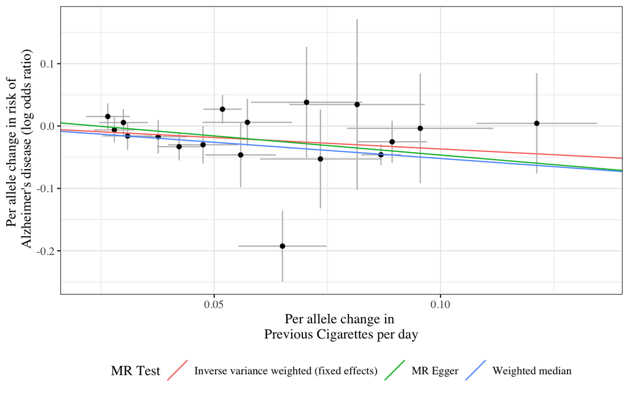

Fig. 1: Scatterplot of SNP effects for the association of Trait and LOAD

Figure 2 and Table 1 shows the SNP-specific effects and overall IVW, weighted median and Egger regression causal estimates of genetically predicted Previous Cigarettes per day on risk of LOAD.

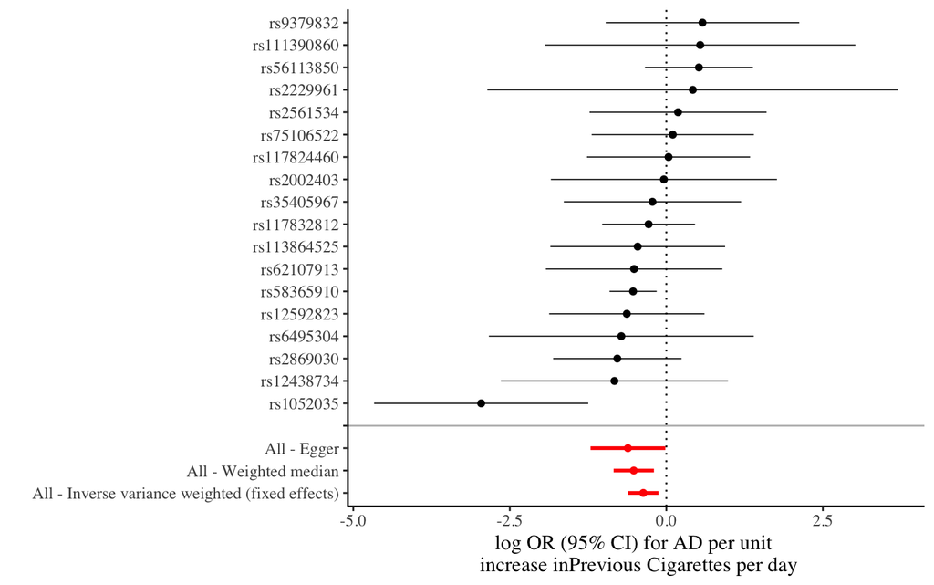

Fig. 2: Forrest plot of Wald ratios and 95% CIs for SNP-specific and overall IVW, Weighted median and Egger associations

**Table 1:** MR estimates for Previous Cigarettes per day and LOAD

|  | SNP | b | se | p |
| --- | --- | --- | --- | --- |
| 1 | rs1052035 | -2.95770255 | 0.8727143 | 0.000701264 |
| 2 | rs111390860 | 0.54119933 | 1.2642189 | 0.668585679 |
| 3 | rs113864525 | -0.45711856 | 0.7122545 | 0.521008865 |
| 4 | rs117824460 | 0.03546363 | 0.6647368 | 0.957453142 |
| 5 | rs117832812 | -0.28330737 | 0.3784897 | 0.454146138 |
| 6 | rs12438734 | -0.82895877 | 0.9256408 | 0.370492478 |
| 7 | rs12592823 | -0.63101170 | 0.6331151 | 0.318920957 |
| 8 | rs2002403 | -0.03873559 | 0.9212788 | 0.966462463 |
| 9 | rs2229961 | 0.42295169 | 1.6746435 | 0.800606523 |
| 10 | rs2561534 | 0.18696956 | 0.7211683 | 0.795435211 |

[output cut: 11 more lines]

Figure 3 shows a funnel plot to detect pleiotropy and Table 2 show the results of Cochrans Q heterogeneity test to assess for the presence of pleiotropy.

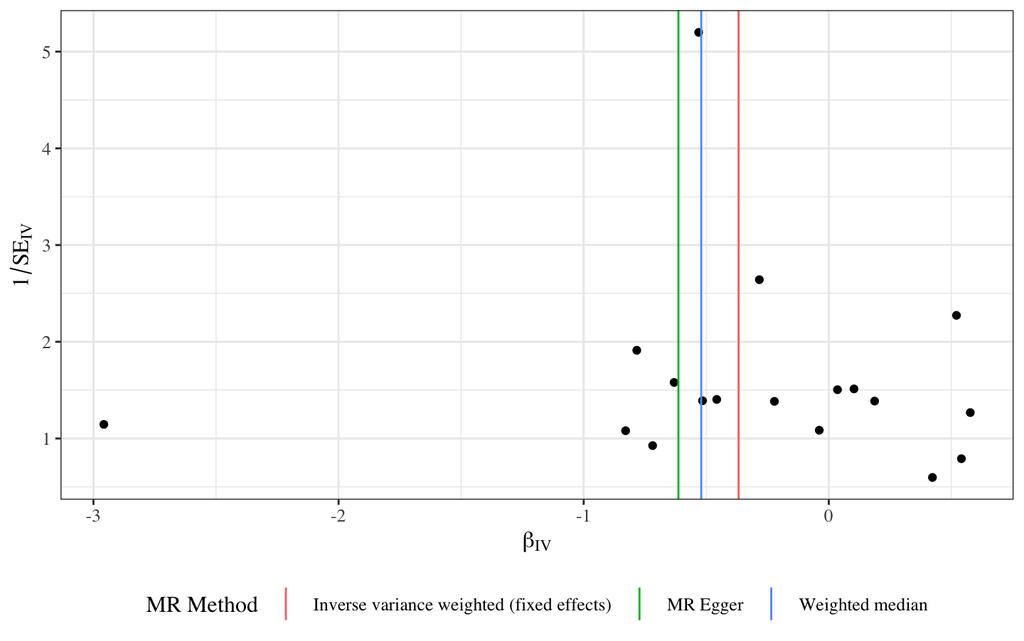

Fig. 3: Funnel plot of the Trait – LOAD causal estimates against their precession

**Table 2:** Heterogenity tests for Previous Cigarettes per day and LOAD

| exposure | outcome | method | Q | Q_df | Q_pval |
| --- | --- | --- | --- | --- | --- |
| cpd | LOAD | MR Egger | 17.79943 | 16 | 0.3357721 |
| cpd | LOAD | Inverse variance weighted | 18.68486 | 17 | 0.3469177 |

**Table 3:** Test for directional pleitropy for Previous Cigarettes per day and LOAD

| id.exposure | id.outcome | outcome | exposure | egger_intercept | se | pval |
| --- | --- | --- | --- | --- | --- | --- |
| U2hXKW | r4cBjj | LOAD | cpd | 0.01480529 | 0.01659518 | 0.3855367 |

### Previous Cigarettes per day ~ AAOS

Figure 4 illustrates the SNP-specific associations with Previous Cigarettes per day versus the association between each SNP and AAOS.

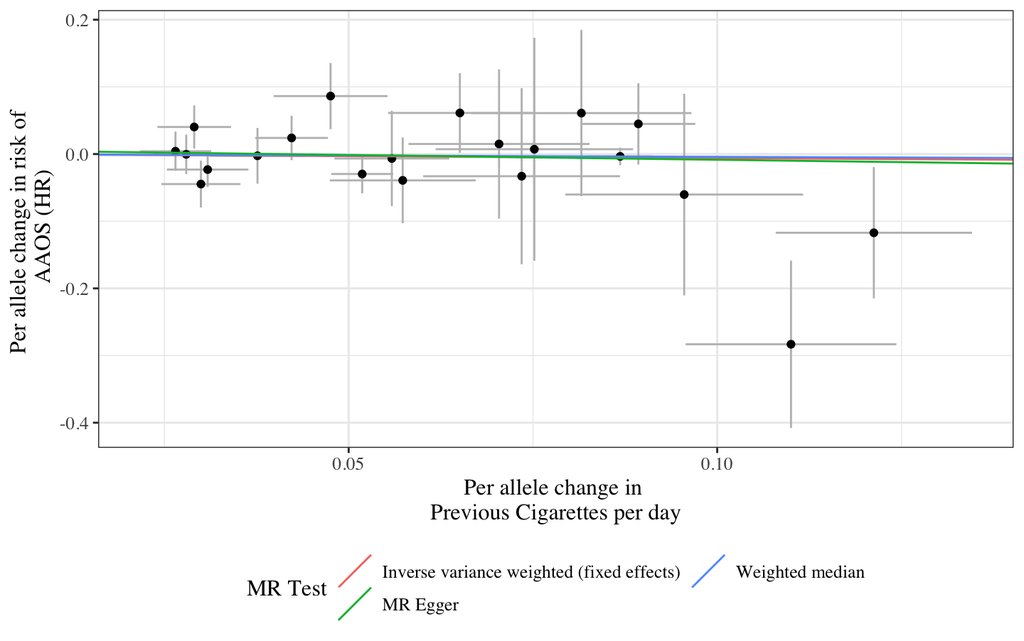

Fig. 4: Scatterplot of SNP effects for the association of Trait and AAOS

Figure 5 and Table 4 shows the SNP-specific effects and overall IVW, weighted median and Egger regression causal estimates of genetically predicted Previous Cigarettes per day on AAOS.

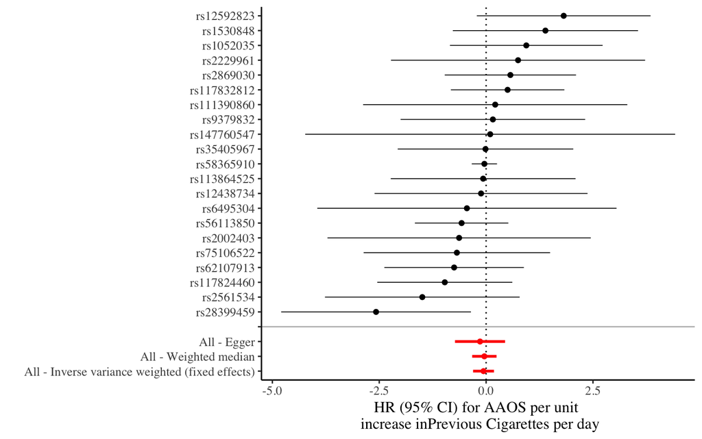

Fig. 5: Forrest plot of Wald ratios and 95% CIs for SNP-specific and overall IVW, Weighted median and Egger associations

**Table 4:** MR estimates for Previous Cigarettes per day and AAOS

|  | SNP | b | se | p |
| --- | --- | --- | --- | --- |
| 1 | rs1052035 | 0.94031894 | 0.9111260 | 0.30205316 |
| 2 | rs111390860 | 0.21307060 | 1.5767225 | 0.89250503 |
| 3 | rs113864525 | -0.06909932 | 1.1029314 | 0.95004473 |
| 4 | rs117824460 | -0.96658997 | 0.8057666 | 0.23029839 |
| 5 | rs117832812 | 0.50278660 | 0.6774742 | 0.45799721 |
| 6 | rs12438734 | -0.11816691 | 1.2711895 | 0.92593713 |
| 7 | rs12592823 | 1.81521033 | 1.0369626 | 0.08003085 |
| 8 | rs147760547 | 0.09575818 | 2.2077580 | 0.96540381 |
| 9 | rs1530848 | 1.38768848 | 1.1053300 | 0.20931483 |
| 10 | rs2002403 | -0.63128537 | 1.5714085 | 0.68788114 |

[output cut: 14 more lines]

Figure 6 shows a funnel plot to detect pleiotropy and Table 5 show the results of Cochrans Q heterogeneity test to assess for the presence of pleiotropy.

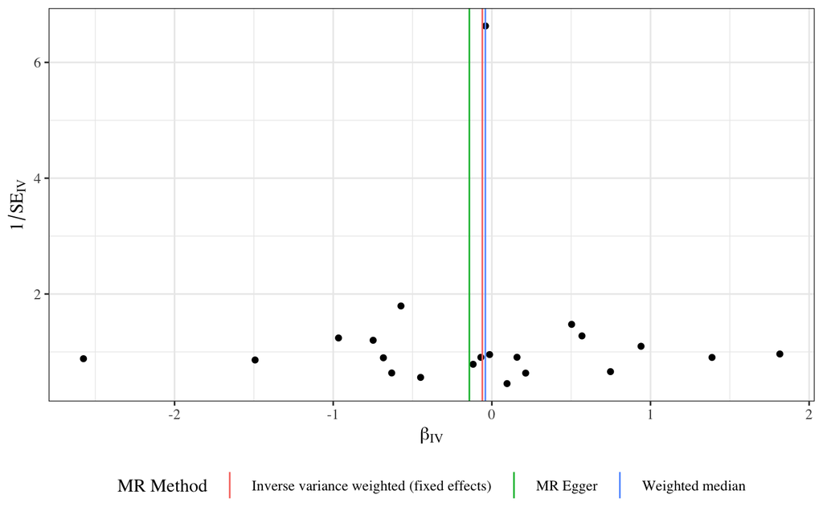

Fig. 6: Funnel plot of the traitohol Conumption – AAOS causal estimates against their precession

**Table 5:** Heterogenity tests for Previous Cigarettes per day and AAOS

| exposure | outcome | method | Q | Q_df | Q_pval |
| --- | --- | --- | --- | --- | --- |
| cpd | AAOS | MR Egger | 17.54940 | 19 | 0.5526994 |
| cpd | AAOS | Inverse variance weighted | 17.64055 | 20 | 0.6110737 |

**Table 6:** Test for directional pleitropy for Previous Cigarettes per day and AAOS

| id.exposure | id.outcome | outcome | exposure | egger_intercept | se | pval |
| --- | --- | --- | --- | --- | --- | --- |
| U2hXKW | mWR8u5 | AAOS | cpd | 0.005706097 | 0.01890029 | 0.766004 |

### Previous Cigarettes per day ~ AB42

Figure 1 illustrates the SNP-specific associations with Previous Cigarettes per day versus the association between each SNP and AB42.

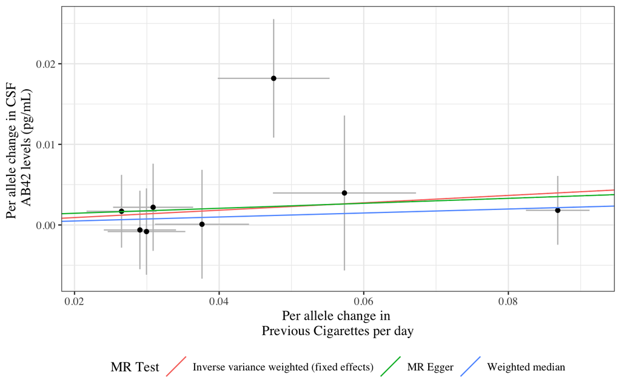

Fig. 1: Scatterplot of SNP effects for the association of trait and AB42

Figure 2 and Table 7 shows the SNP-specific effects and overall IVW, weighted median and Egger regression causal estimates of genetically predicted Previous Cigarettes per day CSF AB42 levels.

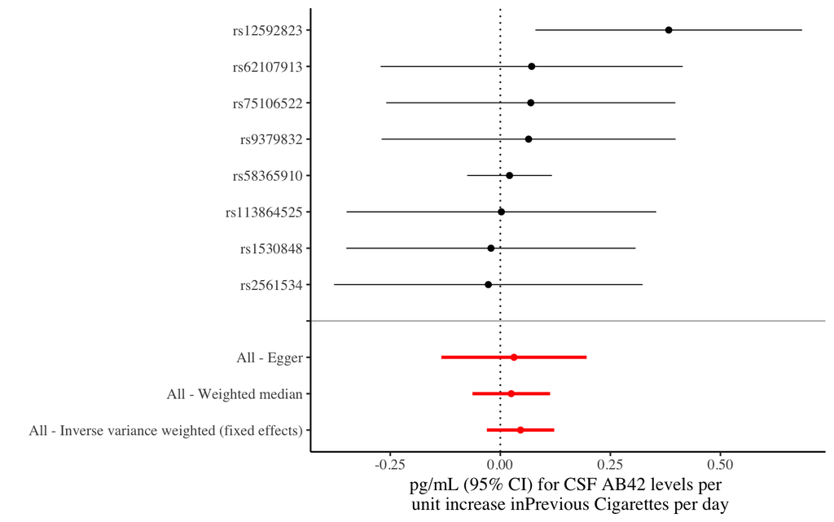

Fig. 2: Forrest plot of Wald ratios and 95% CIs for SNP-specific and overall IVW, Weighted median and Egger associations

**Table 7:** MR estimates for Previous Cigarettes per day and AB42

|  | SNP | b | se | p |
| --- | --- | --- | --- | --- |
| 1 | rs113864525 | 0.002403327 | 0.17939246 | 0.98931103 |
| 2 | rs12592823 | 0.382603428 | 0.15455580 | 0.01330484 |
| 3 | rs1530848 | -0.021249195 | 0.16762450 | 0.89912510 |
| 4 | rs2561534 | -0.027240797 | 0.17882303 | 0.87892364 |
| 5 | rs58365910 | 0.020937368 | 0.04914178 | 0.67006379 |
| 6 | rs62107913 | 0.071207581 | 0.17507087 | 0.68420208 |
| 7 | rs75106522 | 0.069212481 | 0.16760654 | 0.67964603 |
| 8 | rs9379832 | 0.064224719 | 0.17037286 | 0.70619912 |
| 9 | All - Inverse variance weighted (fixed effects) | 0.045925467 | 0.03902660 | 0.23928592 |
| 10 | All - Weighted median | 0.024828555 | 0.04498020 | 0.58095619 |

[output cut: 1 more lines]

Figure 3 shows a funnel plot to detect pleiotropy and Table 8 show the results of Cochrans Q heterogeneity test to assess for the presence of pleiotropy.

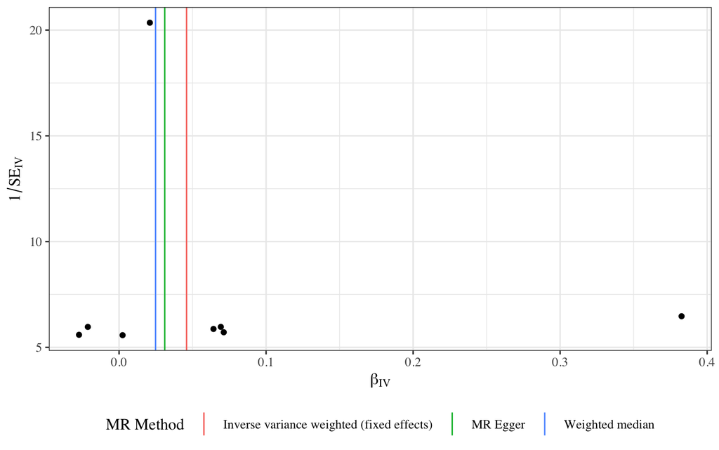

Fig. 3: Funnel plot of the trait – AB42 causal estimates against their precession

**Table 8:** Heterogenity tests for Previous Cigarettes per day and AB42

| exposure | outcome | method | Q | Q_df | Q_pval |
| --- | --- | --- | --- | --- | --- |
| cpd | ab42 | MR Egger | 5.402798 | 6 | 0.4932818 |
| cpd | ab42 | Inverse variance weighted | 5.442366 | 7 | 0.6061444 |

**Table 9:** Test for directional pleitropy for Previous Cigarettes per day and AB42

| id.exposure | id.outcome | outcome | exposure | egger_intercept | se | pval |
| --- | --- | --- | --- | --- | --- | --- |
| U2hXKW | QuLaMK | ab42 | cpd | 0.0008312072 | 0.004178667 | 0.8488972 |

### Previous Cigarettes per day ~ Ptau

Figure 1 illustrates the SNP-specific associations with Previous Cigarettes per day versus the association between each SNP and risk of Ptau.

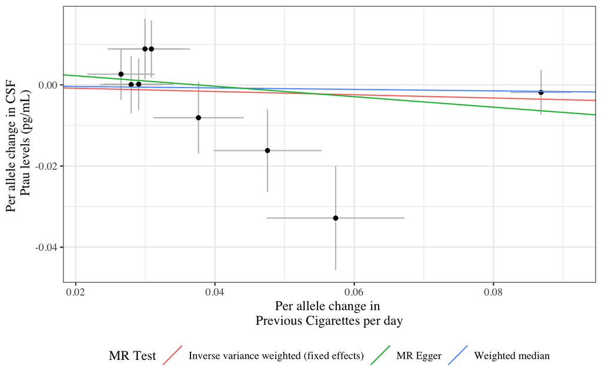

Fig. 1: Scatterplot of SNP effects for the association of trait and Ptau

Figure 2 and Table 9 shows the SNP-specific effects and overall IVW, weighted median and Egger regression causal estimates of genetically predicted Previous Cigarettes per day on risk of Ptau.

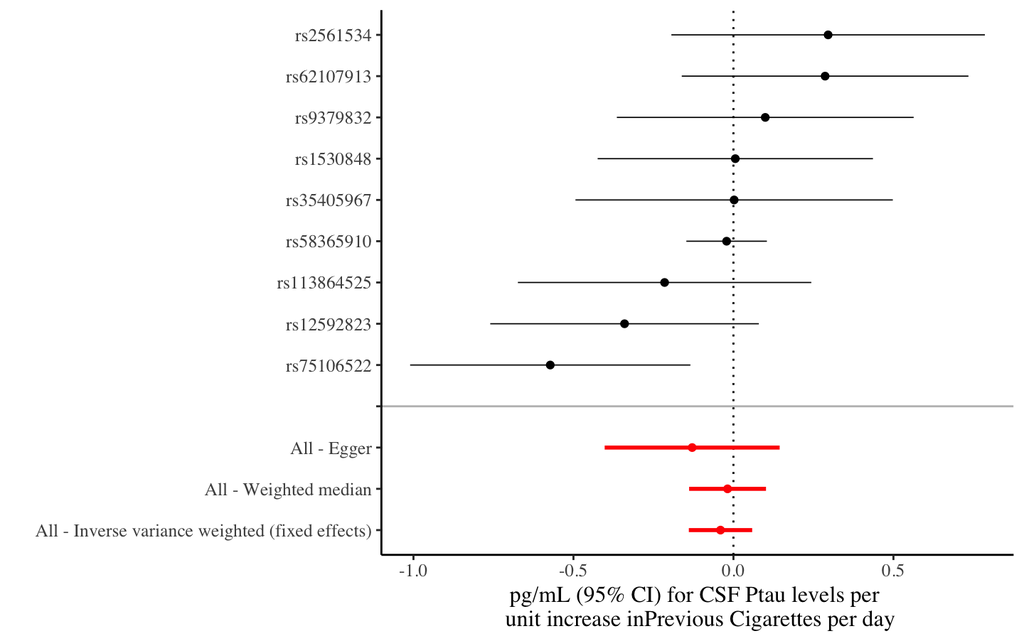

Fig. 2: Forrest plot of Wald ratios and 95% CIs for SNP-specific and overall IVW, Weighted median and Egger associations

**Table 9:** MR estimates for Previous Cigarettes per day and Ptau

|  | SNP | b | se | p |
| --- | --- | --- | --- | --- |
| 1 | rs113864525 | -0.215138066 | 0.23392776 | 0.35774139 |
| 2 | rs12592823 | -0.340325644 | 0.21412330 | 0.11197215 |
| 3 | rs1530848 | 0.005812452 | 0.21948204 | 0.97887242 |
| 4 | rs2561534 | 0.295879325 | 0.24993823 | 0.23648837 |
| 5 | rs35405967 | 0.002197480 | 0.25301063 | 0.99307020 |
| 6 | rs58365910 | -0.021351969 | 0.06420562 | 0.73946942 |
| 7 | rs62107913 | 0.286450150 | 0.22855754 | 0.21009817 |
| 8 | rs75106522 | -0.572468154 | 0.22344050 | 0.01040531 |
| 9 | rs9379832 | 0.099431336 | 0.23663526 | 0.67434800 |
| 10 | All - Inverse variance weighted (fixed effects) | -0.040424100 | 0.05050224 | 0.42345495 |

[output cut: 2 more lines]

Figure 3 shows a funnel plot to detect pleiotropy and Table 10 show the results of Cochrans Q heterogeneity test to assess for the presence of pleiotropy.

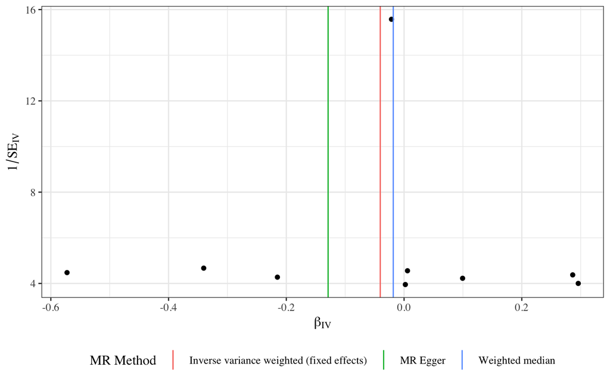

Fig. 3: Funnel plot of the trait – Ptau causal estimates against their precession

**Table 10:** Heterogenity tests for Previous Cigarettes per day and Ptau

| exposure | outcome | method | Q | Q_df | Q_pval |
| --- | --- | --- | --- | --- | --- |
| cpd | ptau | MR Egger | 11.69296 | 7 | 0.1111188 |
| cpd | ptau | Inverse variance weighted | 12.55550 | 8 | 0.1280861 |

**Table 11:** Test for directional pleitropy for Previous Cigarettes per day and Ptau

| id.exposure | id.outcome | outcome | exposure | egger_intercept | se | pval |
| --- | --- | --- | --- | --- | --- | --- |
| U2hXKW | MJUS5W | ptau | cpd | 0.004831286 | 0.006723367 | 0.4956786 |

### Previous Cigarettes per day ~ Tau

Figure 1 illustrates the SNP-specific associations with Previous Cigarettes per day versus the association between each SNP and CSF Tau levels.

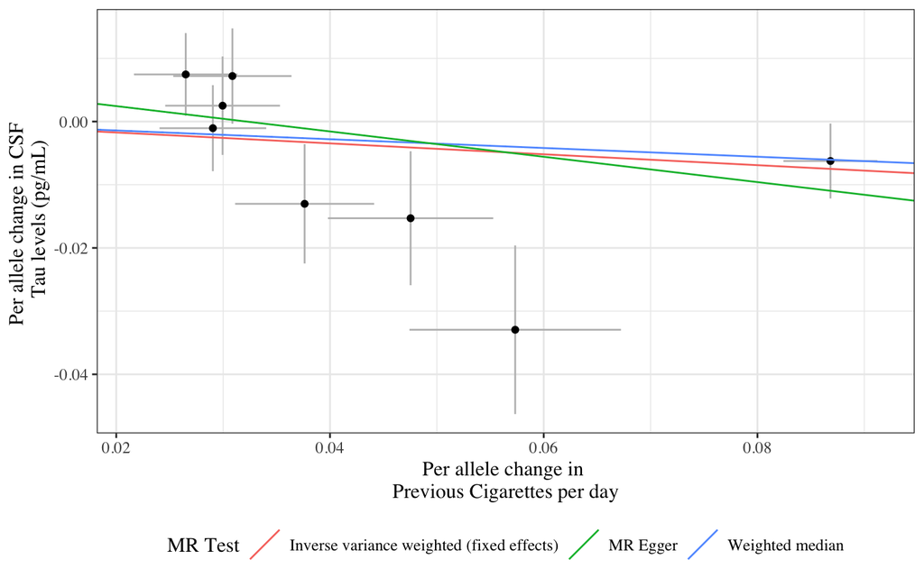

Fig. 1: Scatterplot of SNP effects for the association of trait and Tau

Figure 2 and Table 12 shows the SNP-specific effects and overall IVW, weighted median and Egger regression causal estimates of genetically predicted Previous Cigarettes per day on risk of Tau.

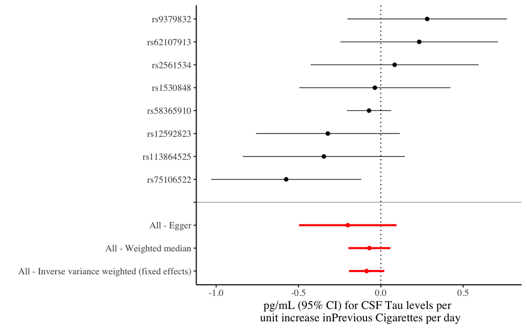

Fig. 2: Forrest plot of Wald ratios and 95% CIs for SNP-specific and overall IVW, Weighted median and Egger associations

**Table 12:** MR estimates for Previous Cigarettes per day and Tau

|  | SNP | b | se | p |
| --- | --- | --- | --- | --- |
| 1 | rs113864525 | -0.34602812 | 0.25088367 | 0.16782160 |
| 2 | rs12592823 | -0.32181597 | 0.22295747 | 0.14890889 |
| 3 | rs1530848 | -0.03612122 | 0.23446082 | 0.87756179 |
| 4 | rs2561534 | 0.08383581 | 0.26018817 | 0.74729191 |
| 5 | rs58365910 | -0.07191030 | 0.06832860 | 0.29260750 |
| 6 | rs62107913 | 0.23325504 | 0.24433466 | 0.33975273 |
| 7 | rs75106522 | -0.57473570 | 0.23268511 | 0.01351074 |
| 8 | rs9379832 | 0.28142653 | 0.24686140 | 0.25427866 |
| 9 | All - Inverse variance weighted (fixed effects) | -0.08627180 | 0.05465342 | 0.11444500 |
| 10 | All - Weighted median | -0.06956719 | 0.06491289 | 0.28385450 |

[output cut: 1 more lines]

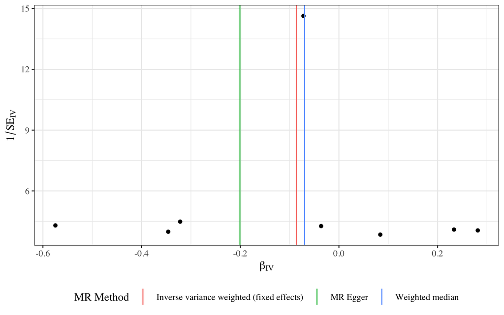

Fig. 3: Funnel plot of the trait – Tau causal estimates against their precession

**Table 14:** Heterogenity tests for Previous Cigarettes per day and Tau

| exposure | outcome | method | Q | Q_df | Q_pval |
| --- | --- | --- | --- | --- | --- |
| cpd | tau | MR Egger | 9.843042 | 6 | 0.1314194 |
| cpd | tau | Inverse variance weighted | 11.041067 | 7 | 0.1368377 |

**Table 15:** Test for directional pleitropy for Previous Cigarettes per day and Tau

| id.exposure | id.outcome | outcome | exposure | egger_intercept | se | pval |
| --- | --- | --- | --- | --- | --- | --- |
| U2hXKW | BIf8HO | tau | cpd | 0.006472259 | 0.00757377 | 0.4255932 |

### Previous Cigarettes per day ~ hippocampal volume

Figure 1 illustrates the SNP-specific associations with Previous Cigarettes per day versus the association between each SNP and hippocampal volume.

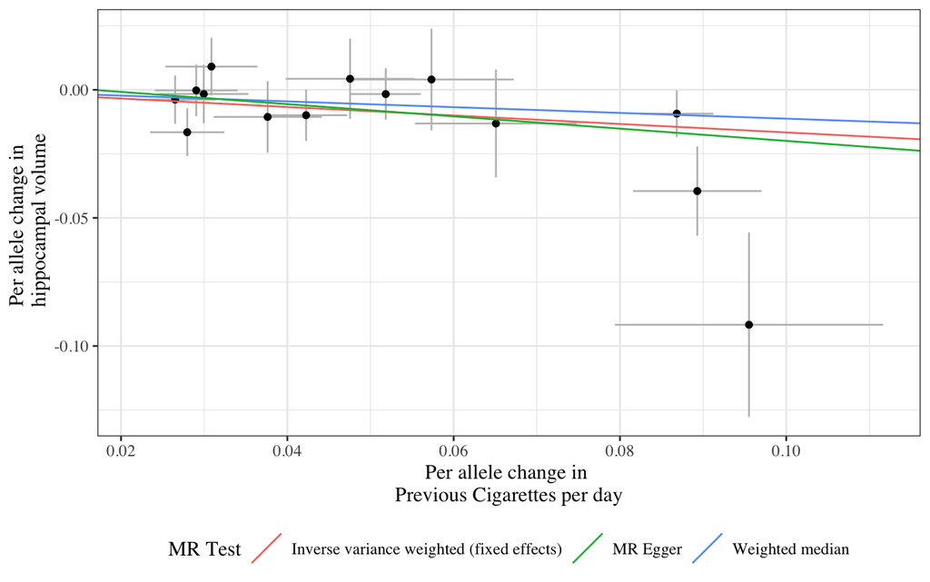

Fig. 1: Scatterplot of SNP effects for the association of trait and hippocampal volume

Figure 2 and Table 12 shows the SNP-specific effects and overall IVW, weighted median and Egger regression causal estimates of genetically predicted Previous Cigarettes per day on risk of hippocampal volume.

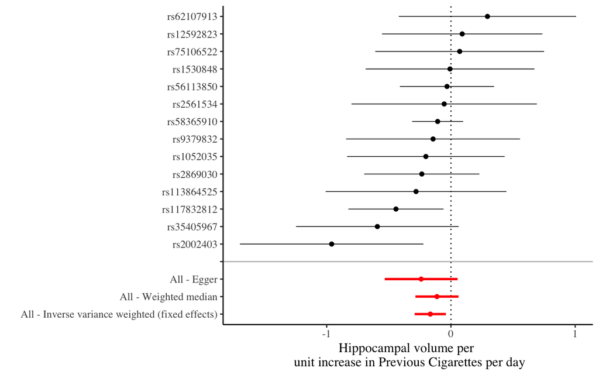

Fig. 2: Forrest plot of Wald ratios and 95% CIs for SNP-specific and overall IVW, Weighted median and Egger associations

**Table 12:** MR estimates for Previous Cigarettes per day and hippocampal volume

|  | SNP | b | se | p |
| --- | --- | --- | --- | --- |
| 1 | rs1052035 | -0.201953199 | 0.32364295 | 0.532627585 |
| 2 | rs113864525 | -0.281024723 | 0.37123477 | 0.449049862 |
| 3 | rs117832812 | -0.442539594 | 0.19538172 | 0.023512680 |
| 4 | rs12592823 | 0.090548021 | 0.32926553 | 0.783316238 |
| 5 | rs1530848 | -0.007622647 | 0.34648394 | 0.982447956 |
| 6 | rs2002403 | -0.960064393 | 0.37679136 | 0.010834247 |
| 7 | rs2561534 | -0.054419451 | 0.38055560 | 0.886290181 |
| 8 | rs2869030 | -0.234584344 | 0.23647615 | 0.321197525 |
| 9 | rs35405967 | -0.592380351 | 0.33392353 | 0.076063150 |
| 10 | rs56113850 | -0.031924449 | 0.19348151 | 0.868943982 |

[output cut: 7 more lines]

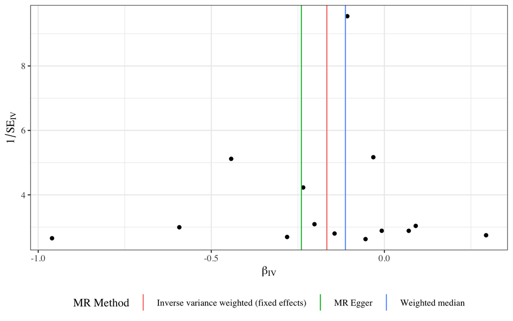

Fig. 3: Funnel plot of the trait – hippocampal volume causal estimates against their precession

**Table 14:** Heterogenity tests for Previous Cigarettes per day and hippocampal volume

| exposure | outcome | method | Q | Q_df | Q_pval |
| --- | --- | --- | --- | --- | --- |
| cpd | hipv | MR Egger | 11.73410 | 12 | 0.4672638 |
| cpd | hipv | Inverse variance weighted | 12.02971 | 13 | 0.5252091 |

**Table 15:** Test for directional pleitropy for Previous Cigarettes per day and hippocampal volume

| id.exposure | id.outcome | outcome | exposure | egger_intercept | se | pval |
| --- | --- | --- | --- | --- | --- | --- |
| U2hXKW | ZdofC3 | hipv | cpd | 0.004044319 | 0.007438512 | 0.5966045 |

## MR analysis results

| exposure | outcome | method | nsnp | b | se | pval | Signif |
| --- | --- | --- | --- | --- | --- | --- | --- |
| cpd | LOAD | IVW | 18 | -0.36794451 | 0.12428911 | 0.003072477 | ** |
| cpd | LOAD | Weighted median | 18 | -0.52033556 | 0.17218897 | 0.002512046 | ** |
| cpd | LOAD | MR Egger | 18 | -0.61347229 | 0.30483786 | 0.061319346 | . |
| cpd | AAOS | IVW | 21 | -0.05996672 | 0.12484535 | 0.630994175 |  |
| cpd | AAOS | Weighted median | 21 | -0.04102333 | 0.14923618 | 0.783401783 |  |
| cpd | AAOS | MR Egger | 21 | -0.14191791 | 0.29878029 | 0.640207861 |  |
| cpd | ab42 | IVW | 8 | 0.04592547 | 0.03902660 | 0.239285923 |  |
| cpd | ab42 | Weighted median | 8 | 0.02482855 | 0.04352908 | 0.568413170 |  |
| cpd | ab42 | MR Egger | 8 | 0.03108446 | 0.08419973 | 0.724674939 |  |
| cpd | ptau | IVW | 9 | -0.04042410 | 0.05050224 | 0.423454952 |  |

[output cut: 8 more lines]